# Seminar 2-1: Confounding factors and human behaviour

University of Sydney

The world is not simple

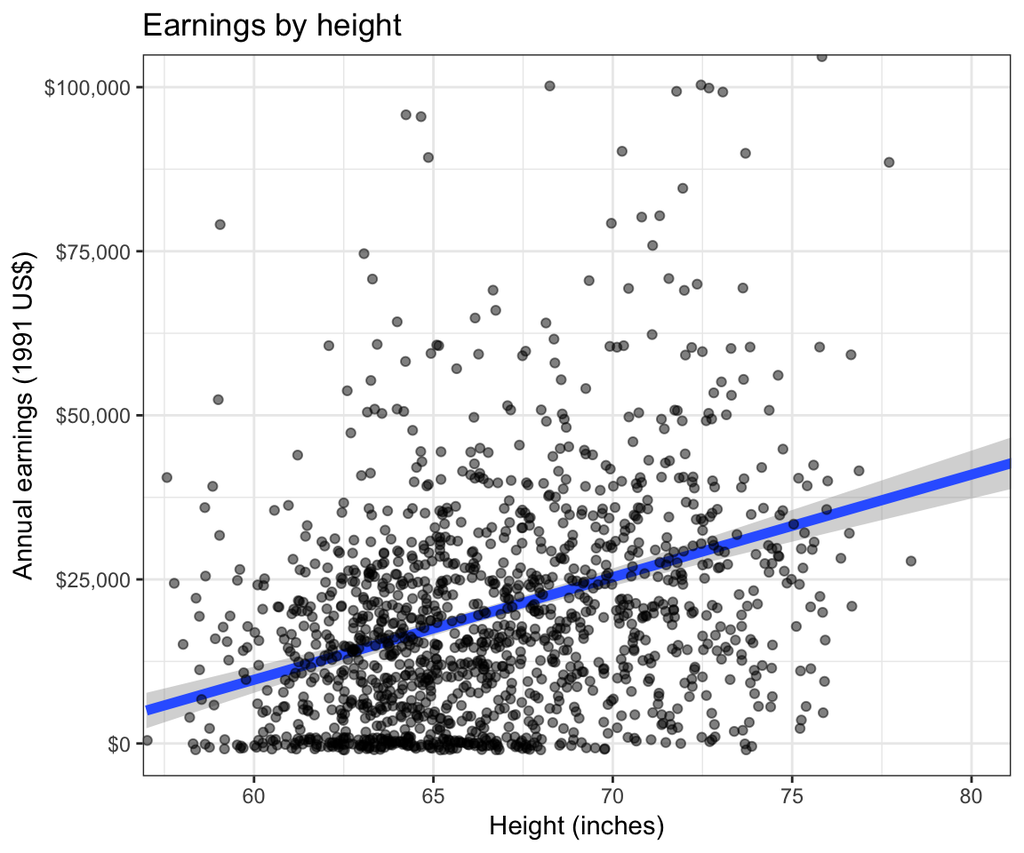

Confounding factors and Simpson's paradox

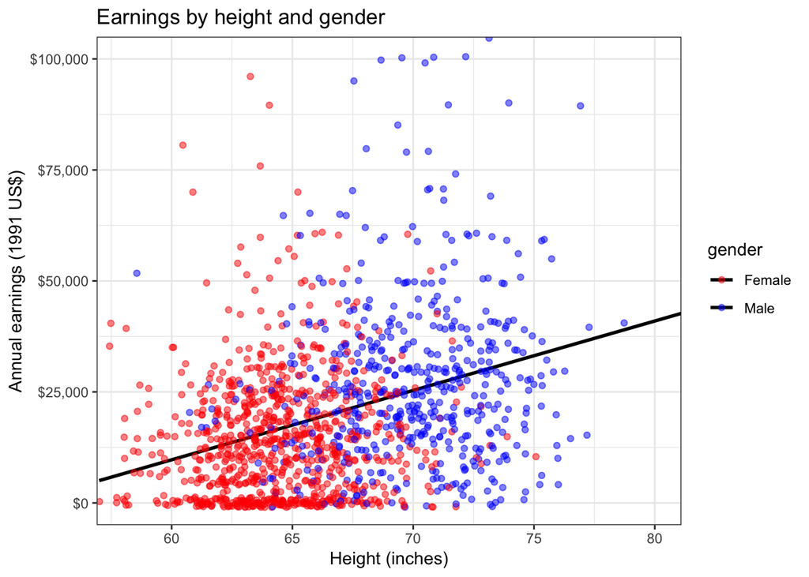

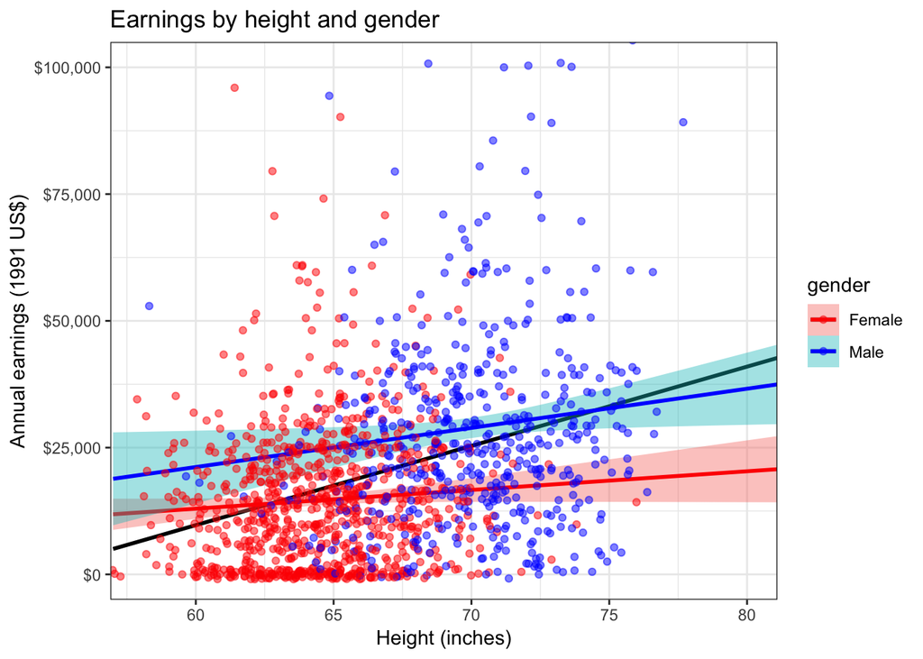

This was made with just this code:

```r
ggplot(earnings.data, aes(y=earn, x=height, colour=gender,
       fill=gender)) +
  geom_smooth(method="lm", fullrange=TRUE,
      colour="black", se=FALSE, aes(group=1)) +
  geom_smooth(method="lm", fullrange=TRUE) +
  geom_jitter(alpha=.5, width = 2, height = 1000) +
  scale_color_manual(values=c("red","blue")) +
  labs(title = "Earnings by height and gender",
       y = "Annual earnings (1991 US$)",
       x = "Height (inches)") +
  scale_y_continuous(labels = dollar,
       breaks = c(0,25000,50000,75000, 100000))+
  coord_cartesian(ylim=c(0,100000), xlim=c(58,80)) +
  theme_bw()
```

Confounding factors and Simpson's paradox

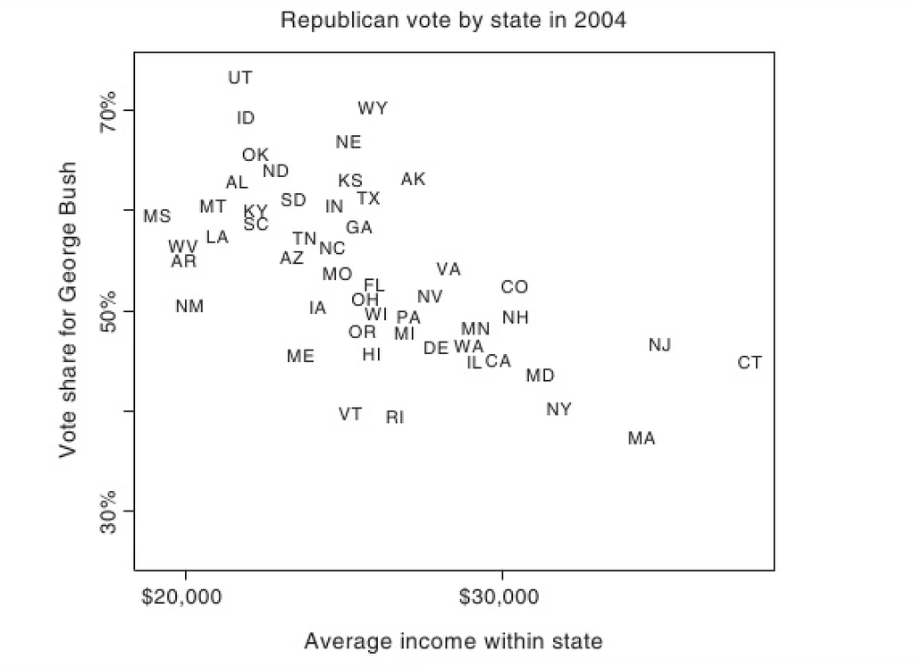

**In US presidential elections, rich states vote Democratic.** Source: Gelman, Park, Shor and Cortina (2008) "Red State, Blue State, Rich State, Poor State: Why Americans Vote the Way They Do".

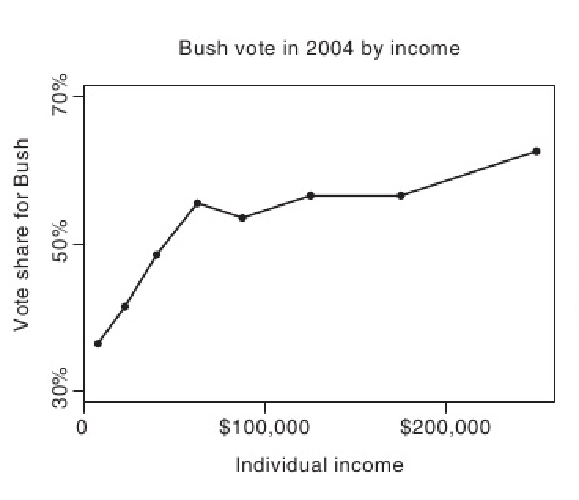

**But, richer voters support the Republican candidate.** Source: Gelman, Park, Shor and Cortina (2008) "Red State, Blue State, Rich State, Poor State: Why Americans Vote the Way They Do".

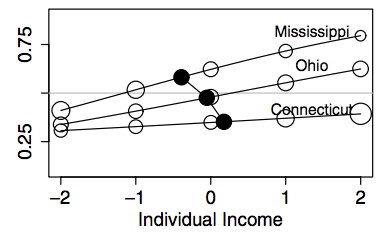

**The reason: there are seperate income-state interactions.** Source: Gelman, Shor, Bafumi and Park (2007) "Rich State, Poor State, Red State, Blue State: What’s the Matter with Connecticut?".

## Linear regression

\(y = \alpha + \beta x + \epsilon\)

## Fitting linear regression in R

```r
earnings.model <- lm(earn ~ z.height + race2 + gender + z.age,
                       data = earnings.data)
display(earnings.model)
```

```
## lm(formula = earn ~ z.height + race2 + gender + z.age, data = earnings.data)
##               coef.est coef.se
## (Intercept)   16444.11   758.48
## z.height       4557.52  1427.38
## race2Black    -2632.00  1742.56
## race2Other     1620.40  3590.42
## race2Hispanic -4072.34  2141.91
## genderMale    11240.25  1450.25
## z.age          4252.46  1137.31
## ---
## n = 1377, k = 7
## residual sd = 18354.27, R-Squared = 0.14
```

## Regression as a tool

- Why use regression?
- Its strengths.
- Its limitations.

## Assumptions

- Additivity and linearity.
  - The expected value of dependent variable is a straight-line function of each independent variable, holding the others fixed.
  - The effects of different independent variables on the expected value of the dependent variable are additive.
- Validity. Your data should map to the research question you are trying to answer.
- Statistical independence of the errors.
  - Little or no multicollinearity.
- Equal variance (homoscedasticity) and normality of errors.

## Randomisation

- Important for social research, particularly samples and surveys.
- Each subject has a known probability of being selected.
- Alternative, convenience sample.
- Helps ensure generalisability.
- Also, experiments.

## Seminar 2-1 labs

- Fitting linear regressions to social science data.
- First hour, a walk-through of the process with your tutor.
- Second hour, group activity.

## Additional tasks

- Not compulsary. Designed to help those less familiar with \(R\), linear regression.
- Revising the methods learned so far.
- Looking at fitting more complex models.

## Additional tasks

The forgetting curve \(R = e^{(-t/s)}\)

[figure not shown]

## Additional tasks

Overcoming the forgetting curve

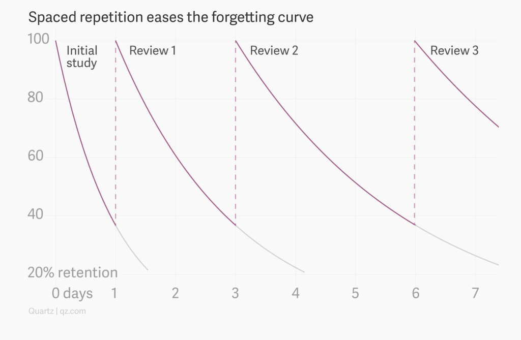

## Contact details

## Contact details

*Dr Shaun Ratcliff*  
Unit coordinator and lecturer  
Email: shaun.ratcliff@sydney.edu.au  
Office: Room N416, Institute Building (H03)

*Nick James*  
Tutor and guest lecturer  
Email: njam4595@uni.sydney.edu.au  
Office: Level 5, The School of Information Technologies, Building J12